# Practical Machine Learning - Course Project

Andreas Hermann

11/12/2018

## Executive summary

This report shows how a simple machine learning predictor can be built to do human activity recognition based on movement data. We try to predict the same 5 classes (sitting-down, standing-up, standing, walking, and sitting) with our own model.

We will address these main points:

- Model Building using Cross Validation
- Discussion of Sample Error
- Prediction of Test Cases

## Build Model

Load the data and do some exploratory analysis.

```r
training <- data.frame(read.csv2('pml-training.csv', sep = ',', dec = '.', na.strings = c('#DIV/0!', 'NA'), stringsAsFactors = TRUE))
testing <- data.frame(read.csv2('pml-testing.csv', sep = ',', dec = '.', na.strings = c('#DIV/0!', 'NA'), stringsAsFactors = TRUE))
```

Browse the data

```r
head(training)
```

[output not shown]

[output cut: 265 more lines]

See the outcome distribution

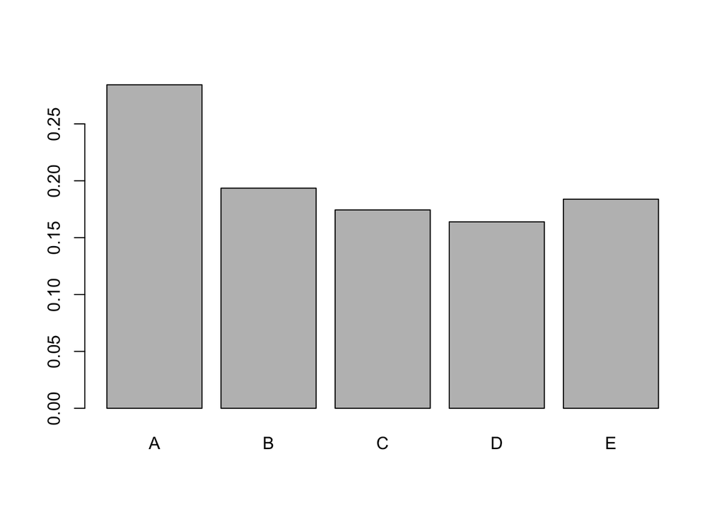

### Data Cleansing

Find the number of incomplete columns

```r
length(colnames(training)[colSums(is.na(training)) > 0])
```

```
## [1] 100
```

Remove columns containing NA values, as it is hard to predict the class for unknown values

```r
na.cols <- colnames(training)[apply(training, 2, anyNA)]
training[na.cols] <- NULL
```

Remove some columns that should not be used for the model

```r
training['X'] <- NULL
training['cvtd_timestamp'] <- NULL
training['user_name'] <- NULL
training['new_window'] <- NULL
```

### Training

Train a Random Forests model using 5-fold cross validation with the random forest method of caret package. Execute the code in parallel to speed up processing.

```r
cluster <- makeCluster(detectCores() - 1) # convention to leave 1 core for OS
registerDoParallel(cluster)

control <- trainControl(method = "cv", number = 5, allowParallel = TRUE)
modFitRF <- train(classe ~ ., data=training, method="rf", trControl = control)

stopCluster(cluster)
```

Analyse the accuracy and of the trained model

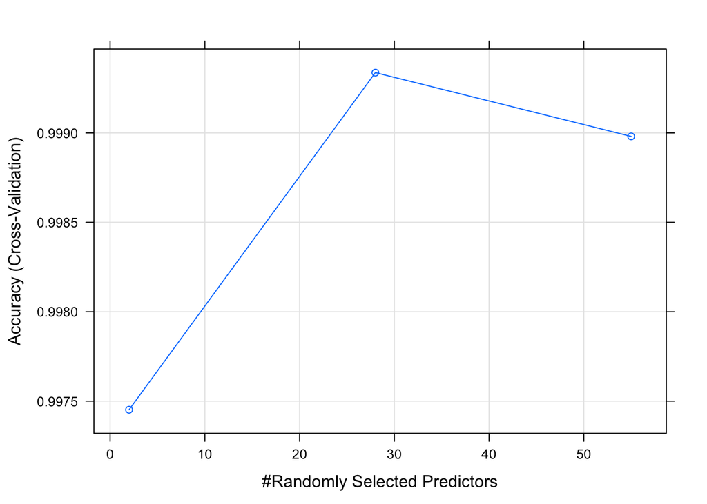

```r
plot(modFitRF)
```

Given an accuracy of 99% on the training data for out-of-bag values we should expect a similar accuracy on out of sample data.

## Prediction

Predict the class of the test data using our trained random forest model

```r
pRF <- predict(modFitRF, newdata=testing)
table(testing$X, pRF)
```

```
##     pRF
##      A B C D E
##   1  0 1 0 0 0
##   2  1 0 0 0 0
##   3  0 1 0 0 0
##   4  1 0 0 0 0
##   5  1 0 0 0 0
##   6  0 0 0 0 1
##   7  0 0 0 1 0
##   8  0 1 0 0 0
##   9  1 0 0 0 0
##   10 1 0 0 0 0
##   11 0 1 0 0 0
##   12 0 0 1 0 0
##   13 0 1 0 0 0
##   14 1 0 0 0 0
##   15 0 0 0 0 1
##   16 0 0 0 0 1
##   17 1 0 0 0 0
##   18 0 1 0 0 0
##   19 0 1 0 0 0
##   20 0 1 0 0 0
```

The predicted data is less equally distributed into the five classes than the observed training data.

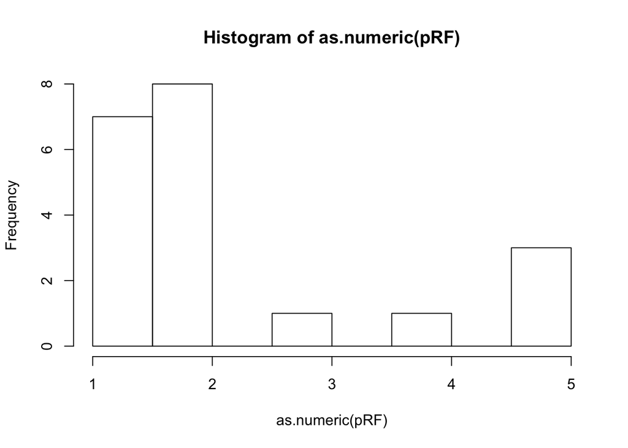

```r
hist(as.numeric(pRF))
```